# R Notebook Wrangle

## Data Cleaning with R

The process of identifying, correcting, or removing inaccurate raw data for downstream purposes. Or, more colloquially, an unglamorous yet wholely necessary first step towards an analysis-ready.

### Check List

- Familiarize yourself with the data set
- Check for structural errors
- Check for data irregularities
- Decide how to deal with missing values
- Document data versions and changes made

### Step 1: Familiarize yourself with the data set

An important “pre-data cleaning” Step is **Domain Knowledge**.

The data file we’re utilizing is 1104203 bytes or 1.01MB.

```r
str(df) # Show structure of data frame
```

```r
#Install if the package doesn't exist
update.packages()
```

# Why Do we need clean data?

- Access Data
- Explore and Process Data
- Extract Insights
- Report Insights

## Data type constraints

- Text or in R is character
- Integer - integer - numeric
- Binary - logical
- Category - factor
- Date - date

```r
edidiv <- read.csv("./CC-RBasics/edidiv.csv")
head(edidiv)
```

### Glimpsin at data tupes

```r
library(dplyr)
glimpse(edidiv)
```

**Note** : This help you to see the data type in the data set.

### Checking data types

- `is.character()`
- `is.numeric()`
- `is.logical`
- for all `data types`

```r
is.numeric(edidiv$year)
```

```r
install.packages("assertive")
```

```r
library(assertive)
assert_is_factor(edidiv$taxonName)
```

```r
class(edidiv$organisationName)
```

```
[1] "factor"
```

```r
mean(edidiv$taxonName)
```

### Comma problems

```r
library("tidyverse")
```

```r
comma_problems <- c("5,454", "5,456", "3,456", "6,789")
```

```r
library(stringr)
```

```r
revenue_trimed = str_remove(comma_problems, ",")
revenue_trimed
```

### Character to Numeric

```r
as.numeric(revenue_trimed)
```

### Putting it together

```r
edidiv %>%
  mutate(
    grid_mod = as.numeric(
      str_remove(gridReference, "NT")
    )
  )
```

# Google class - data cleaning

The next packages are important for data cleaning process in R:

```r
install.packages("here")
```

```r
library('here')
```

The goal of the here package is to enable easy file referencing in project-oriented workflows.  
In contrast to using setwd(), which is fragile and dependent on the way you organize your files,  
here uses the top-level directory of a project to easily build paths to files.

```r
install.packages("skimr")
```

```r
library("skimr")
```

skimr is designed to provide summary statistics about variables in data frames, tibbles, data tables and vectors. It is opinionated in its defaults, but easy to modify.

```r
install.packages("janitor")
```

```r
library("janitor")
```

The janitor package is a R package that has simple functions for examining and cleaning dirty data. It was built with beginning and intermediate R users in mind and is optimised for user-friendliness

```r
install.packages("dplyr")
```

```r
library("dplyr")
```

**dplyr** is a grammar of data manipulation, providing a consistent set of verbs that help you solve the most common data manipulation challenges:

- mutate() adds new variables that are functions of existing variables
- select() picks variables based on their names.
- filter() picks cases based on their values.
- summarise() reduces multiple values down to a single summary.
- arrange() changes the ordering of the rows.

```r
install.packages("palmerpenguins")
```

```r
install.packages("remotes")
```

```r
library("remotes")
```

```r
library("palmerpenguins")
```

### Data explored

```r
skim_without_charts(penguins)
```

```
── Data Summary ────────────────────────
                           Values
Name                       penguins
Number of rows             344
Number of columns          8
_______________________
Column type frequency:
  factor                   3
  numeric                  5
________________________
Group variables            None

── Variable type: factor ───────────────────────────────────────────────────────────────────────────────────────────────────
  skim_variable n_missing complete_rate ordered n_unique top_counts
1 species               0         1     FALSE          3 Ade: 152, Gen: 124, Chi: 68
2 island                0         1     FALSE          3 Bis: 168, Dre: 124, Tor: 52
3 sex                  11         0.968 FALSE          2 mal: 168, fem: 165

── Variable type: numeric ──────────────────────────────────────────────────────────────────────────────────────────────────
  skim_variable     n_missing complete_rate   mean      sd     p0    p25    p50    p75   p100
1 bill_length_mm            2         0.994   43.9   5.46    32.1   39.2   44.4   48.5   59.6
2 bill_depth_mm             2         0.994   17.2   1.97    13.1   15.6   17.3   18.7   21.5
3 flipper_length_mm         2         0.994  201.   14.1    172    190    197    213    231
4 body_mass_g               2         0.994 4202.  802.    2700   3550   4050   4750   6300
5 year                      0         1     2008.    0.818 2007   2007   2008   2009   2009
```

```r
glimpse(penguins)
```

```
Rows: 344
Columns: 8
$ species           <fct> Adelie, Adelie, Adelie, Adelie, Adelie, Adelie, Adelie, Adelie, Adelie, Adelie, Adelie, Adelie, …
$ island            <fct> Torgersen, Torgersen, Torgersen, Torgersen, Torgersen, Torgersen, Torgersen, Torgersen, Torgerse…
$ bill_length_mm    <dbl> 39.1, 39.5, 40.3, NA, 36.7, 39.3, 38.9, 39.2, 34.1, 42.0, 37.8, 37.8, 41.1, 38.6, 34.6, 36.6, 38…
$ bill_depth_mm     <dbl> 18.7, 17.4, 18.0, NA, 19.3, 20.6, 17.8, 19.6, 18.1, 20.2, 17.1, 17.3, 17.6, 21.2, 21.1, 17.8, 19…
$ flipper_length_mm <int> 181, 186, 195, NA, 193, 190, 181, 195, 193, 190, 186, 180, 182, 191, 198, 185, 195, 197, 184, 19…
$ body_mass_g       <int> 3750, 3800, 3250, NA, 3450, 3650, 3625, 4675, 3475, 4250, 3300, 3700, 3200, 3800, 4400, 3700, 34…
$ sex               <fct> male, female, female, NA, female, male, female, male, NA, NA, NA, NA, female, male, male, female…
$ year              <int> 2007, 2007, 2007, 2007, 2007, 2007, 2007, 2007, 2007, 2007, 2007, 2007, 2007, 2007, 2007, 2007, …
```

```r
head(penguins)
```

| species | island | bill_length_mm | bill_depth_mm | flipper_length_mm | body_mass_g | sex | year |
| --- | --- | --- | --- | --- | --- | --- | --- |
| Adelie | Torgersen | 39.1 | 18.7 | 181 | 3750 | male | 2007 |
| Adelie | Torgersen | 39.5 | 17.4 | 186 | 3800 | female | 2007 |
| Adelie | Torgersen | 40.3 | 18.0 | 195 | 3250 | female | 2007 |
| Adelie | Torgersen | NA | NA | NA | NA | NA | 2007 |
| Adelie | Torgersen | 36.7 | 19.3 | 193 | 3450 | female | 2007 |
| Adelie | Torgersen | 39.3 | 20.6 | 190 | 3650 | male | 2007 |

```r
penguins %>%
  select(species)
```

| species |
| --- |
| Adelie |
| Adelie |
| Adelie |
| Adelie |
| Adelie |
| Adelie |
| Adelie |
| Adelie |
| Adelie |
| Adelie |

[output cut: 334 more lines]

```r
penguins %>%
  select(-species) # Excluded species from penguins dataset
```

| island | bill_length_mm | bill_depth_mm | flipper_length_mm | body_mass_g | sex | year |
| --- | --- | --- | --- | --- | --- | --- |
| Torgersen | 39.1 | 18.7 | 181 | 3750 | male | 2007 |
| Torgersen | 39.5 | 17.4 | 186 | 3800 | female | 2007 |
| Torgersen | 40.3 | 18.0 | 195 | 3250 | female | 2007 |
| Torgersen | NA | NA | NA | NA | NA | 2007 |
| Torgersen | 36.7 | 19.3 | 193 | 3450 | female | 2007 |
| Torgersen | 39.3 | 20.6 | 190 | 3650 | male | 2007 |
| Torgersen | 38.9 | 17.8 | 181 | 3625 | female | 2007 |
| Torgersen | 39.2 | 19.6 | 195 | 4675 | male | 2007 |
| Torgersen | 34.1 | 18.1 | 193 | 3475 | NA | 2007 |
| Torgersen | 42.0 | 20.2 | 190 | 4250 | NA | 2007 |

[output cut: 334 more lines]

### Transform

```r
penguins_fail <- rename( penguins, isl = island) # Rename columns
```

```r
rename_with(penguins, toupper)
```

| SPECIES | ISLAND | BILL_LENGTH_MM | BILL_DEPTH_MM | FLIPPER_LENGTH_MM | BODY_MASS_G | SEX | YEAR |
| --- | --- | --- | --- | --- | --- | --- | --- |
| Adelie | Torgersen | 39.1 | 18.7 | 181 | 3750 | male | 2007 |
| Adelie | Torgersen | 39.5 | 17.4 | 186 | 3800 | female | 2007 |
| Adelie | Torgersen | 40.3 | 18.0 | 195 | 3250 | female | 2007 |
| Adelie | Torgersen | NA | NA | NA | NA | NA | 2007 |
| Adelie | Torgersen | 36.7 | 19.3 | 193 | 3450 | female | 2007 |
| Adelie | Torgersen | 39.3 | 20.6 | 190 | 3650 | male | 2007 |
| Adelie | Torgersen | 38.9 | 17.8 | 181 | 3625 | female | 2007 |
| Adelie | Torgersen | 39.2 | 19.6 | 195 | 4675 | male | 2007 |
| Adelie | Torgersen | 34.1 | 18.1 | 193 | 3475 | NA | 2007 |
| Adelie | Torgersen | 42.0 | 20.2 | 190 | 4250 | NA | 2007 |

[output cut: 334 more lines]

## File Convention

#### **Do**

- Keep your filenames to a reasonable length
- Use underscores and hyphens for readability
- Start or end your filename with a letter or number
- Use a standard date format when applicable; example: YYYY-MM-DD
- Use filenames for related files that work well with default ordering; example: in chronological order, or logical order using numbers first

| Examples of good filenames |
| --- |
| 2020-04-10_march-attendance.R |
| 2021_03_20_new_customer_ids.csv |
| 01_data-sales.html |
| 02_data-sales.html |

### **Arithmetic operators**

| Operator | Description | Example Code | Result/ Output |
| --- | --- | --- | --- |
| + | Addition | x + y | [1] 7 |
| - | Subtraction | x - y | [1] -3 |
| * | Multiplication | x * y | [1] 10 |
| / | Division | x / y | [1] 0.4 |
| %% | Modulus (returns the remainder after division) | y %% x | [1] 1 |
| %/% | Integer division (returns an integer value after division) | y%/% x | [1] 2 |
| ^ | Exponent | y ^ x | [1]25 |

### **Relational operators**

| **Operator** | **Description** | Example Code | Result/Output |
| --- | --- | --- | --- |
| < | Less than | x < y | [1] TRUE |
| > | Greater than | x > y | [1] FALSE |
| <= | Less than or equal to | x < = 2 | [1] TRUE |
| >= | Greater than or equal to | y >= 10 | [1] FALSE |
| == | Equal to | y == 5 | [1] TRUE |
| != | Not equal to | x != 2 | [1] FALSE |

### **Logical operators**

| **Operator** | **Description** |
| --- | --- |
| & | Element-wise logical AND |
| && | Logical AND |
| \| | Element-wise logical OR |
| \|\| | Logical OR |
| ! | Logical NOT |

```r
x <- c(3, 5, 7)

y <- c(2, 4, 6)
```

```r
x < 5 & y < 5 # all elements tested
```

```
[1]  TRUE FALSE FALSE
```

```r
x < 5 && y < 5 # first element tested
```

```
[1] TRUE
```

## Organize your data

```r
penguins %>%
  arrange(-bill_length_mm)
```

| species | island | bill_length_mm | bill_depth_mm | flipper_length_mm | body_mass_g | sex | year |
| --- | --- | --- | --- | --- | --- | --- | --- |
| Gentoo | Biscoe | 59.6 | 17.0 | 230 | 6050 | male | 2007 |
| Chinstrap | Dream | 58.0 | 17.8 | 181 | 3700 | female | 2007 |
| Gentoo | Biscoe | 55.9 | 17.0 | 228 | 5600 | male | 2009 |
| Chinstrap | Dream | 55.8 | 19.8 | 207 | 4000 | male | 2009 |
| Gentoo | Biscoe | 55.1 | 16.0 | 230 | 5850 | male | 2009 |
| Gentoo | Biscoe | 54.3 | 15.7 | 231 | 5650 | male | 2008 |
| Chinstrap | Dream | 54.2 | 20.8 | 201 | 4300 | male | 2008 |
| Chinstrap | Dream | 53.5 | 19.9 | 205 | 4500 | male | 2008 |
| Gentoo | Biscoe | 53.4 | 15.8 | 219 | 5500 | male | 2009 |
| Chinstrap | Dream | 52.8 | 20.0 | 205 | 4550 | male | 2008 |

[output cut: 334 more lines]

#### Arrange

```r
penguins_2 <- penguins %>%
  arrange(-bill_length_mm) # Organized desc - form penguins

penguins_2 # bill is pico in spanish
```

| species | island | bill_length_mm | bill_depth_mm | flipper_length_mm | body_mass_g | sex | year |
| --- | --- | --- | --- | --- | --- | --- | --- |
| Gentoo | Biscoe | 59.6 | 17.0 | 230 | 6050 | male | 2007 |
| Chinstrap | Dream | 58.0 | 17.8 | 181 | 3700 | female | 2007 |
| Gentoo | Biscoe | 55.9 | 17.0 | 228 | 5600 | male | 2009 |
| Chinstrap | Dream | 55.8 | 19.8 | 207 | 4000 | male | 2009 |
| Gentoo | Biscoe | 55.1 | 16.0 | 230 | 5850 | male | 2009 |
| Gentoo | Biscoe | 54.3 | 15.7 | 231 | 5650 | male | 2008 |
| Chinstrap | Dream | 54.2 | 20.8 | 201 | 4300 | male | 2008 |
| Chinstrap | Dream | 53.5 | 19.9 | 205 | 4500 | male | 2008 |
| Gentoo | Biscoe | 53.4 | 15.8 | 219 | 5500 | male | 2009 |
| Chinstrap | Dream | 52.8 | 20.0 | 205 | 4550 | male | 2008 |

[output cut: 334 more lines]

```r
library(tidyverse)
```

#### Group By

```r
# Careful with drop_na
penguins %>%
  group_by(island) %>%
  drop_na() %>% # eleminated na values in the data set
  summarize(mean_bill_length_mm = mean(bill_length_mm))
```

| island | mean_bill_length_mm |
| --- | --- |
| Biscoe | 45.24847 |
| Dream | 44.22195 |
| Torgersen | 39.03830 |

```r
NA
```

```r
penguins %>%
  group_by(island) %>%
  drop_na() %>% # eleminated na values in the data set
  summarize(max_bill_length_mm = max(bill_length_mm))
```

| island | max_bill_length_mm |
| --- | --- |
| Biscoe | 59.6 |
| Dream | 58.0 |
| Torgersen | 46.0 |

```r
penguins %>%
  drop_na() %>%
  summarize(min(bill_length_mm))
```

| min(bill_length_mm) |
| --- |
| 32.1 |

```r
penguins %>%
  group_by(island) %>%
  drop_na() %>% # eleminated na values in the data set
  summarize(min_bill_length_mm = min(bill_length_mm))
```

| island | min_bill_length_mm |
| --- | --- |
| Biscoe | 34.5 |
| Dream | 32.1 |
| Torgersen | 33.5 |

```r
penguins %>%
  group_by(species, island) %>%
  drop_na() %>% # eleminated na values in the data set
  summarize(max_bl = max(bill_length_mm), mean_bl = mean(bill_length_mm))
```

| species | island | max_bl | mean_bl |
| --- | --- | --- | --- |
| Adelie | Biscoe | 45.6 | 38.97500 |
| Adelie | Dream | 44.1 | 38.52000 |
| Adelie | Torgersen | 46.0 | 39.03830 |
| Chinstrap | Dream | 58.0 | 48.83382 |
| Gentoo | Biscoe | 59.6 | 47.56807 |

#### Filters

```r
penguins %>%
  filter(species == 'Adelie')
```

| species | island | bill_length_mm | bill_depth_mm | flipper_length_mm | body_mass_g | sex | year |
| --- | --- | --- | --- | --- | --- | --- | --- |
| Adelie | Torgersen | 39.1 | 18.7 | 181 | 3750 | male | 2007 |
| Adelie | Torgersen | 39.5 | 17.4 | 186 | 3800 | female | 2007 |
| Adelie | Torgersen | 40.3 | 18.0 | 195 | 3250 | female | 2007 |
| Adelie | Torgersen | NA | NA | NA | NA | NA | 2007 |
| Adelie | Torgersen | 36.7 | 19.3 | 193 | 3450 | female | 2007 |
| Adelie | Torgersen | 39.3 | 20.6 | 190 | 3650 | male | 2007 |
| Adelie | Torgersen | 38.9 | 17.8 | 181 | 3625 | female | 2007 |
| Adelie | Torgersen | 39.2 | 19.6 | 195 | 4675 | male | 2007 |
| Adelie | Torgersen | 34.1 | 18.1 | 193 | 3475 | NA | 2007 |
| Adelie | Torgersen | 42.0 | 20.2 | 190 | 4250 | NA | 2007 |

[output cut: 142 more lines]

## Transforming data

```r
id <- c(1:10)

name <- c("John Mendes", "Rob Stewart", "Rachel Abrahamson", "Christy Hickman", "Johnson Harper", "Candace Miller", "Carlson Landy", "Pansy Jordan", "Darius Berry", "Claudia Garcia")

job_title <- c("Professional", "Programmer", "Management", "Clerical", "Developer", "Programmer", "Management", "Clerical", "Developer", "Programmer")

employee <- data.frame(id, name, job_title)
```

```r
print(employee)
```

| id | name | job_title |
| --- | --- | --- |
| 1 | John Mendes | Professional |
| 2 | Rob Stewart | Programmer |
| 3 | Rachel Abrahamson | Management |
| 4 | Christy Hickman | Clerical |
| 5 | Johnson Harper | Developer |
| 6 | Candace Miller | Programmer |
| 7 | Carlson Landy | Management |
| 8 | Pansy Jordan | Clerical |
| 9 | Darius Berry | Developer |
| 10 | Claudia Garcia | Programmer |

#### Separate

```r
employee_name <- separate(employee, name, into=c("first_name", "last_name"), sep= ' ')
```

```r
print(employee_name)
```

| id | first_name | last_name | job_title |
| --- | --- | --- | --- |
| 1 | John | Mendes | Professional |
| 2 | Rob | Stewart | Programmer |
| 3 | Rachel | Abrahamson | Management |
| 4 | Christy | Hickman | Clerical |
| 5 | Johnson | Harper | Developer |
| 6 | Candace | Miller | Programmer |
| 7 | Carlson | Landy | Management |
| 8 | Pansy | Jordan | Clerical |
| 9 | Darius | Berry | Developer |
| 10 | Claudia | Garcia | Programmer |

#### Unite

```r
unite(employee_name, 'name', first_name, last_name)
```

| id | name | job_title |
| --- | --- | --- |
| 1 | John_Mendes | Professional |
| 2 | Rob_Stewart | Programmer |
| 3 | Rachel_Abrahamson | Management |
| 4 | Christy_Hickman | Clerical |
| 5 | Johnson_Harper | Developer |
| 6 | Candace_Miller | Programmer |
| 7 | Carlson_Landy | Management |
| 8 | Pansy_Jordan | Clerical |
| 9 | Darius_Berry | Developer |
| 10 | Claudia_Garcia | Programmer |

```r
unite(employee_name, 'name', first_name, last_name, sep = ' ')
```

| id | name | job_title |
| --- | --- | --- |
| 1 | John Mendes | Professional |
| 2 | Rob Stewart | Programmer |
| 3 | Rachel Abrahamson | Management |
| 4 | Christy Hickman | Clerical |
| 5 | Johnson Harper | Developer |
| 6 | Candace Miller | Programmer |
| 7 | Carlson Landy | Management |
| 8 | Pansy Jordan | Clerical |
| 9 | Darius Berry | Developer |
| 10 | Claudia Garcia | Programmer |

#### Mutate

```r
penguins_edit <- penguins %>%
  mutate(body_mass_kg = body_mass_g/1000, flipper_length_m = flipper_length_mm/1000)
```

```r
View(penguins_edit)
```

## Wide to long with tidyr

**Wide data** has observations across several columns. Each column contains data from a different condition of the variable. In this example, different years.

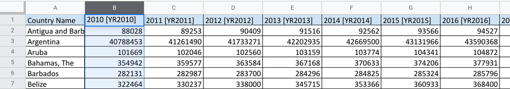

screenshot of a spreadsheet in wide format. there are 7 rows shown and 8 columns

And, to review what you already learned about the difference, **long data** has all the observations in a single column, and variables in separate columns.

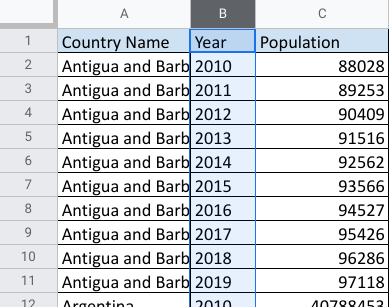

screenshot of spreadsheet in long format. there are 12 rows shown and 3 columns

### The pivot_longer and pivot_wider functions

[`pivot_longer()`](https://tidyr.tidyverse.org/reference/pivot_longer.html) can work with multiple value variables that may have different types, inspired by the enhanced `melt()` and `dcast()` functions provided by the [data.table](https://github.com/Rdatatable/data.table/wiki) package by Matt Dowle and Arun Srinivasan.

[`pivot_longer()`](https://tidyr.tidyverse.org/reference/pivot_longer.html) and [`pivot_wider()`](https://tidyr.tidyverse.org/reference/pivot_wider.html) can take a data frame that specifies precisely how metadata stored in column names becomes data variables (and vice versa), inspired by the [cdata](https://winvector.github.io/cdata/) package by John Mount and Nina Zumel.

```r
library(tidyr)
library(dplyr)
library(readr)
```

```r
relig_income
```

| religion | <$10k | $10-20k | $20-30k | $30-40k | $40-50k | $50-75k | $75-100k | $100-150k | >150k | Don't know/refused |
| --- | --- | --- | --- | --- | --- | --- | --- | --- | --- | --- |
| Agnostic | 27 | 34 | 60 | 81 | 76 | 137 | 122 | 109 | 84 | 96 |
| Atheist | 12 | 27 | 37 | 52 | 35 | 70 | 73 | 59 | 74 | 76 |
| Buddhist | 27 | 21 | 30 | 34 | 33 | 58 | 62 | 39 | 53 | 54 |
| Catholic | 418 | 617 | 732 | 670 | 638 | 1116 | 949 | 792 | 633 | 1489 |
| Don’t know/refused | 15 | 14 | 15 | 11 | 10 | 35 | 21 | 17 | 18 | 116 |
| Evangelical Prot | 575 | 869 | 1064 | 982 | 881 | 1486 | 949 | 723 | 414 | 1529 |
| Hindu | 1 | 9 | 7 | 9 | 11 | 34 | 47 | 48 | 54 | 37 |
| Historically Black Prot | 228 | 244 | 236 | 238 | 197 | 223 | 131 | 81 | 78 | 339 |
| Jehovah's Witness | 20 | 27 | 24 | 24 | 21 | 30 | 15 | 11 | 6 | 37 |
| Jewish | 19 | 19 | 25 | 25 | 30 | 95 | 69 | 87 | 151 | 162 |

[output cut: 8 more lines]

This dataset contains three variables:

- `religion`, stored in the rows,
- `income` spread across the column names, and
- `count` stored in the cell values.

[output not shown]

```r
billboard
```

| artist | track | date.entered | wk1 | wk2 | wk3 | wk4 | wk5 | wk6 | wk7 | wk8 | wk9 | wk10 | wk11 | wk12 | wk13 | wk14 | wk15 | wk16 | wk17 | wk18 | wk19 | wk20 | wk21 | wk22 | wk23 | wk24 | wk25 | wk26 | wk27 | … |
| --- | --- | --- | --- | --- | --- | --- | --- | --- | --- | --- | --- | --- | --- | --- | --- | --- | --- | --- | --- | --- | --- | --- | --- | --- | --- | --- | --- | --- | --- | --- |
| 2 Pac | Baby Don't Cry (Keep... | 2000-02-26 | 87 | 82 | 72 | 77 | 87 | 94 | 99 | NA | NA | NA | NA | NA | NA | NA | NA | NA | NA | NA | NA | NA | NA | NA | NA | NA | NA | NA | NA | … |
| 2Ge+her | The Hardest Part Of ... | 2000-09-02 | 91 | 87 | 92 | NA | NA | NA | NA | NA | NA | NA | NA | NA | NA | NA | NA | NA | NA | NA | NA | NA | NA | NA | NA | NA | NA | NA | NA | … |
| 3 Doors Down | Kryptonite | 2000-04-08 | 81 | 70 | 68 | 67 | 66 | 57 | 54 | 53 | 51 | 51 | 51 | 51 | 47 | 44 | 38 | 28 | 22 | 18 | 18 | 14 | 12 | 7 | 6 | 6 | 6 | 5 | 5 | … |
| 3 Doors Down | Loser | 2000-10-21 | 76 | 76 | 72 | 69 | 67 | 65 | 55 | 59 | 62 | 61 | 61 | 59 | 61 | 66 | 72 | 76 | 75 | 67 | 73 | 70 | NA | NA | NA | NA | NA | NA | NA | … |
| 504 Boyz | Wobble Wobble | 2000-04-15 | 57 | 34 | 25 | 17 | 17 | 31 | 36 | 49 | 53 | 57 | 64 | 70 | 75 | 76 | 78 | 85 | 92 | 96 | NA | NA | NA | NA | NA | NA | NA | NA | NA | … |
| 98^0 | Give Me Just One Nig... | 2000-08-19 | 51 | 39 | 34 | 26 | 26 | 19 | 2 | 2 | 3 | 6 | 7 | 22 | 29 | 36 | 47 | 67 | 66 | 84 | 93 | 94 | NA | NA | NA | NA | NA | NA | NA | … |
| A*Teens | Dancing Queen | 2000-07-08 | 97 | 97 | 96 | 95 | 100 | NA | NA | NA | NA | NA | NA | NA | NA | NA | NA | NA | NA | NA | NA | NA | NA | NA | NA | NA | NA | NA | NA | … |
| Aaliyah | I Don't Wanna | 2000-01-29 | 84 | 62 | 51 | 41 | 38 | 35 | 35 | 38 | 38 | 36 | 37 | 37 | 38 | 49 | 61 | 63 | 62 | 67 | 83 | 86 | NA | NA | NA | NA | NA | NA | NA | … |
| Aaliyah | Try Again | 2000-03-18 | 59 | 53 | 38 | 28 | 21 | 18 | 16 | 14 | 12 | 10 | 9 | 8 | 6 | 1 | 2 | 2 | 2 | 2 | 3 | 4 | 5 | 5 | 6 | 9 | 13 | 14 | 16 | … |
| Adams, Yolanda | Open My Heart | 2000-08-26 | 76 | 76 | 74 | 69 | 68 | 67 | 61 | 58 | 57 | 59 | 66 | 68 | 61 | 67 | 59 | 63 | 67 | 71 | 79 | 89 | NA | NA | NA | NA | NA | NA | NA | … |

[output cut: 307 more lines]

```r
NA
```

```r
billboard %>%
  pivot_longer(
    cols = starts_with("wk"),
    names_to = "week",
    values_to = "rank",
    values_drop_na = TRUE
  )
```

[output not shown]

```r
billboard %>%
  pivot_longer(
    cols = starts_with("wk"),
    names_to = "week",
    names_prefix = "wk",
    names_transform = list(week = as.integer),
    values_to = "rank",
    values_drop_na = TRUE,
  )
```

| artist | track | date.entered | week | rank |
| --- | --- | --- | --- | --- |
| 2 Pac | Baby Don't Cry (Keep... | 2000-02-26 | 1 | 87 |
| 2 Pac | Baby Don't Cry (Keep... | 2000-02-26 | 2 | 82 |
| 2 Pac | Baby Don't Cry (Keep... | 2000-02-26 | 3 | 72 |
| 2 Pac | Baby Don't Cry (Keep... | 2000-02-26 | 4 | 77 |
| 2 Pac | Baby Don't Cry (Keep... | 2000-02-26 | 5 | 87 |
| 2 Pac | Baby Don't Cry (Keep... | 2000-02-26 | 6 | 94 |
| 2 Pac | Baby Don't Cry (Keep... | 2000-02-26 | 7 | 99 |
| 2Ge+her | The Hardest Part Of ... | 2000-09-02 | 1 | 91 |
| 2Ge+her | The Hardest Part Of ... | 2000-09-02 | 2 | 87 |
| 2Ge+her | The Hardest Part Of ... | 2000-09-02 | 3 | 92 |

[output cut: 990 more lines]

```r
billboard %>%
  pivot_longer(
    cols = starts_with("wk"),
    names_to = "week",
    names_transform = list(week = readr::parse_number),
    values_to = "rank",
    values_drop_na = TRUE,
  )
```

| artist | track | date.entered | week | rank |
| --- | --- | --- | --- | --- |
| 2 Pac | Baby Don't Cry (Keep... | 2000-02-26 | 1 | 87 |
| 2 Pac | Baby Don't Cry (Keep... | 2000-02-26 | 2 | 82 |
| 2 Pac | Baby Don't Cry (Keep... | 2000-02-26 | 3 | 72 |
| 2 Pac | Baby Don't Cry (Keep... | 2000-02-26 | 4 | 77 |
| 2 Pac | Baby Don't Cry (Keep... | 2000-02-26 | 5 | 87 |
| 2 Pac | Baby Don't Cry (Keep... | 2000-02-26 | 6 | 94 |
| 2 Pac | Baby Don't Cry (Keep... | 2000-02-26 | 7 | 99 |
| 2Ge+her | The Hardest Part Of ... | 2000-09-02 | 1 | 91 |
| 2Ge+her | The Hardest Part Of ... | 2000-09-02 | 2 | 87 |
| 2Ge+her | The Hardest Part Of ... | 2000-09-02 | 3 | 92 |

[output cut: 990 more lines]

```r
NA
```

### Many variables in column names

```r
who
```

| country | iso2 | iso3 | year | new_sp_m014 | new_sp_m1524 | new_sp_m2534 | new_sp_m3544 | new_sp_m4554 | new_sp_m5564 | new_sp_m65 | new_sp_f014 | new_sp_f1524 | new_sp_f2534 | new_sp_f3544 | new_sp_f4554 | new_sp_f5564 | new_sp_f65 | new_sn_m014 | new_sn_m1524 | new_sn_m2534 | new_sn_m3544 | new_sn_m4554 | new_sn_m5564 | new_sn_m65 | new_sn_f014 | new_sn_f1524 | new_sn_f2534 | new_sn_f3544 | new_sn_f4554 | … |
| --- | --- | --- | --- | --- | --- | --- | --- | --- | --- | --- | --- | --- | --- | --- | --- | --- | --- | --- | --- | --- | --- | --- | --- | --- | --- | --- | --- | --- | --- | --- |
| Afghanistan | AF | AFG | 1980 | NA | NA | NA | NA | NA | NA | NA | NA | NA | NA | NA | NA | NA | NA | NA | NA | NA | NA | NA | NA | NA | NA | NA | NA | NA | NA | … |
| Afghanistan | AF | AFG | 1981 | NA | NA | NA | NA | NA | NA | NA | NA | NA | NA | NA | NA | NA | NA | NA | NA | NA | NA | NA | NA | NA | NA | NA | NA | NA | NA | … |
| Afghanistan | AF | AFG | 1982 | NA | NA | NA | NA | NA | NA | NA | NA | NA | NA | NA | NA | NA | NA | NA | NA | NA | NA | NA | NA | NA | NA | NA | NA | NA | NA | … |
| Afghanistan | AF | AFG | 1983 | NA | NA | NA | NA | NA | NA | NA | NA | NA | NA | NA | NA | NA | NA | NA | NA | NA | NA | NA | NA | NA | NA | NA | NA | NA | NA | … |
| Afghanistan | AF | AFG | 1984 | NA | NA | NA | NA | NA | NA | NA | NA | NA | NA | NA | NA | NA | NA | NA | NA | NA | NA | NA | NA | NA | NA | NA | NA | NA | NA | … |
| Afghanistan | AF | AFG | 1985 | NA | NA | NA | NA | NA | NA | NA | NA | NA | NA | NA | NA | NA | NA | NA | NA | NA | NA | NA | NA | NA | NA | NA | NA | NA | NA | … |
| Afghanistan | AF | AFG | 1986 | NA | NA | NA | NA | NA | NA | NA | NA | NA | NA | NA | NA | NA | NA | NA | NA | NA | NA | NA | NA | NA | NA | NA | NA | NA | NA | … |
| Afghanistan | AF | AFG | 1987 | NA | NA | NA | NA | NA | NA | NA | NA | NA | NA | NA | NA | NA | NA | NA | NA | NA | NA | NA | NA | NA | NA | NA | NA | NA | NA | … |
| Afghanistan | AF | AFG | 1988 | NA | NA | NA | NA | NA | NA | NA | NA | NA | NA | NA | NA | NA | NA | NA | NA | NA | NA | NA | NA | NA | NA | NA | NA | NA | NA | … |
| Afghanistan | AF | AFG | 1989 | NA | NA | NA | NA | NA | NA | NA | NA | NA | NA | NA | NA | NA | NA | NA | NA | NA | NA | NA | NA | NA | NA | NA | NA | NA | NA | … |

[output cut: 990 more lines]

```r
who %>% pivot_longer(
  cols = new_sp_m014:newrel_f65,
  names_to = c("diagnosis", "gender", "age"),
  names_pattern = "new_?(.*)_(.)(.*)",
  values_to = "count"
)
```

| country | iso2 | iso3 | year | diagnosis | gender | age | count |
| --- | --- | --- | --- | --- | --- | --- | --- |
| Afghanistan | AF | AFG | 1980 | sp | m | 014 | NA |
| Afghanistan | AF | AFG | 1980 | sp | m | 1524 | NA |
| Afghanistan | AF | AFG | 1980 | sp | m | 2534 | NA |
| Afghanistan | AF | AFG | 1980 | sp | m | 3544 | NA |
| Afghanistan | AF | AFG | 1980 | sp | m | 4554 | NA |
| Afghanistan | AF | AFG | 1980 | sp | m | 5564 | NA |
| Afghanistan | AF | AFG | 1980 | sp | m | 65 | NA |
| Afghanistan | AF | AFG | 1980 | sp | f | 014 | NA |
| Afghanistan | AF | AFG | 1980 | sp | f | 1524 | NA |
| Afghanistan | AF | AFG | 1980 | sp | f | 2534 | NA |

[output cut: 990 more lines]

```r
who %>% pivot_longer(
  cols = new_sp_m014:newrel_f65,
  names_to = c("diagnosis", "gender", "age"),
  names_pattern = "new_?(.*)_(.)(.*)",
  names_transform = list(
    gender = ~ readr::parse_factor(.x, levels = c("f", "m")),
    age = ~ readr::parse_factor(
      .x,
      levels = c("014", "1524", "2534", "3544", "4554", "5564", "65"),
      ordered = TRUE
    )
  ),
  values_to = "count",
)
```

| country | iso2 | iso3 | year | diagnosis | gender | age | count |
| --- | --- | --- | --- | --- | --- | --- | --- |
| Afghanistan | AF | AFG | 1980 | sp | m | 014 | NA |
| Afghanistan | AF | AFG | 1980 | sp | m | 1524 | NA |
| Afghanistan | AF | AFG | 1980 | sp | m | 2534 | NA |
| Afghanistan | AF | AFG | 1980 | sp | m | 3544 | NA |
| Afghanistan | AF | AFG | 1980 | sp | m | 4554 | NA |
| Afghanistan | AF | AFG | 1980 | sp | m | 5564 | NA |
| Afghanistan | AF | AFG | 1980 | sp | m | 65 | NA |
| Afghanistan | AF | AFG | 1980 | sp | f | 014 | NA |
| Afghanistan | AF | AFG | 1980 | sp | f | 1524 | NA |
| Afghanistan | AF | AFG | 1980 | sp | f | 2534 | NA |

[output cut: 990 more lines]

## Wider

```r
fish_encounters
```

| fish | station | seen |
| --- | --- | --- |
| 4842 | Release | 1 |
| 4842 | I80_1 | 1 |
| 4842 | Lisbon | 1 |
| 4842 | Rstr | 1 |
| 4842 | Base_TD | 1 |
| 4842 | BCE | 1 |
| 4842 | BCW | 1 |
| 4842 | BCE2 | 1 |
| 4842 | BCW2 | 1 |
| 4842 | MAE | 1 |

[output cut: 104 more lines]

```r
fish_encounters %>% pivot_wider(names_from = station, values_from = seen)
```

| fish | Release | I80_1 | Lisbon | Rstr | Base_TD | BCE | BCW | BCE2 | BCW2 | MAE | MAW |
| --- | --- | --- | --- | --- | --- | --- | --- | --- | --- | --- | --- |
| 4842 | 1 | 1 | 1 | 1 | 1 | 1 | 1 | 1 | 1 | 1 | 1 |
| 4843 | 1 | 1 | 1 | 1 | 1 | 1 | 1 | 1 | 1 | 1 | 1 |
| 4844 | 1 | 1 | 1 | 1 | 1 | 1 | 1 | 1 | 1 | 1 | 1 |
| 4845 | 1 | 1 | 1 | 1 | 1 | NA | NA | NA | NA | NA | NA |
| 4847 | 1 | 1 | 1 | NA | NA | NA | NA | NA | NA | NA | NA |
| 4848 | 1 | 1 | 1 | 1 | NA | NA | NA | NA | NA | NA | NA |
| 4849 | 1 | 1 | NA | NA | NA | NA | NA | NA | NA | NA | NA |
| 4850 | 1 | 1 | NA | 1 | 1 | 1 | 1 | NA | NA | NA | NA |
| 4851 | 1 | 1 | NA | NA | NA | NA | NA | NA | NA | NA | NA |
| 4854 | 1 | 1 | NA | NA | NA | NA | NA | NA | NA | NA | NA |

[output cut: 9 more lines]

```r
fish_encounters %>% pivot_wider(
  names_from = station,
  values_from = seen,
  values_fill = 0
)
```

| fish | Release | I80_1 | Lisbon | Rstr | Base_TD | BCE | BCW | BCE2 | BCW2 | MAE | MAW |
| --- | --- | --- | --- | --- | --- | --- | --- | --- | --- | --- | --- |
| 4842 | 1 | 1 | 1 | 1 | 1 | 1 | 1 | 1 | 1 | 1 | 1 |
| 4843 | 1 | 1 | 1 | 1 | 1 | 1 | 1 | 1 | 1 | 1 | 1 |
| 4844 | 1 | 1 | 1 | 1 | 1 | 1 | 1 | 1 | 1 | 1 | 1 |
| 4845 | 1 | 1 | 1 | 1 | 1 | 0 | 0 | 0 | 0 | 0 | 0 |
| 4847 | 1 | 1 | 1 | 0 | 0 | 0 | 0 | 0 | 0 | 0 | 0 |
| 4848 | 1 | 1 | 1 | 1 | 0 | 0 | 0 | 0 | 0 | 0 | 0 |
| 4849 | 1 | 1 | 0 | 0 | 0 | 0 | 0 | 0 | 0 | 0 | 0 |
| 4850 | 1 | 1 | 0 | 1 | 1 | 1 | 1 | 0 | 0 | 0 | 0 |
| 4851 | 1 | 1 | 0 | 0 | 0 | 0 | 0 | 0 | 0 | 0 | 0 |
| 4854 | 1 | 1 | 0 | 0 | 0 | 0 | 0 | 0 | 0 | 0 | 0 |

[output cut: 9 more lines]

```r
warpbreaks <- warpbreaks %>% as_tibble() %>% select(wool, tension, breaks)
warpbreaks
```

| wool | tension | breaks |
| --- | --- | --- |
| A | L | 26 |
| A | L | 30 |
| A | L | 54 |
| A | L | 25 |
| A | L | 70 |
| A | L | 52 |
| A | L | 51 |
| A | L | 26 |
| A | L | 67 |
| A | M | 18 |

[output cut: 44 more lines]

```r
warpbreaks %>% count(wool, tension)
```

| wool | tension | n |
| --- | --- | --- |
| A | L | 9 |
| A | M | 9 |
| A | H | 9 |
| B | L | 9 |
| B | M | 9 |
| B | H | 9 |

```r
warpbreaks %>% pivot_wider(names_from = wool, values_from = breaks)
```

```
Values are not uniquely identified; output will contain list-cols.
* Use `values_fn = list` to suppress this warning.
* Use `values_fn = length` to identify where the duplicates arise
* Use `values_fn = {summary_fun}` to summarise duplicates
```

| tension | A | B |
| --- | --- | --- |
| L |  |  |
| M |  |  |
| H |  |  |

```r
warpbreaks %>%
  pivot_wider(
    names_from = wool,
    values_from = breaks,
    values_fn = list(breaks = mean)
  )
```

| tension | A | B |
| --- | --- | --- |
| L | 44.55556 | 28.22222 |
| M | 24.00000 | 28.77778 |
| H | 24.55556 | 18.77778 |